# Social Distance and Age

Kendra Seaman

July 06, 2020

# Temporal Discounting Social Distancing Study 2

|  | colnames(data) | Q5 |
| --- | --- | --- |
| 1 | Q5 | 1 [NaN, NaN] |
| 2 | Q10 | 0.04 [-0.08, 0.17] |
| 3 | Q11 | -0.03 [-0.15, 0.1] |
| 4 | Q12 | -0.08 [-0.2, 0.05] |
| 5 | Q13 | -0.18 [-0.3, -0.06] |
| 6 | Q14 | -0.12 [-0.24, 0] |
| 7 | Q18 | -0.01 [-0.13, 0.12] |
| 8 | Q23_1 | 0.15 [0.02, 0.27] |
| 9 | Q24_1 | 0.06 [-0.07, 0.18] |
| 10 | Q25 | 0.28 [0.16, 0.39] |
| 14 | SC0 | -0.03 [-0.16, 0.1] |
| 15 | SC1 | -0.22 [-0.33, -0.09] |
| 16 | SC2 | -0.03 [-0.16, 0.1] |

Q23_1 = How likely do you think you are to catch COVID-19/coronavirus?

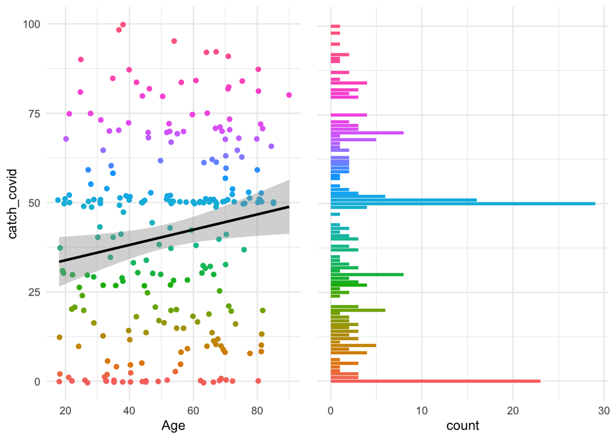

Q25 = What is the most likely outcome if you caught COVID-19/coronavirus?

1 = Recover without serious symptoms or complications (like a typical flu), 2 = Have serious symptoms (more than a typical flu) but recover at home, 3 = Have to be hospitalized, 4 = Would not survive

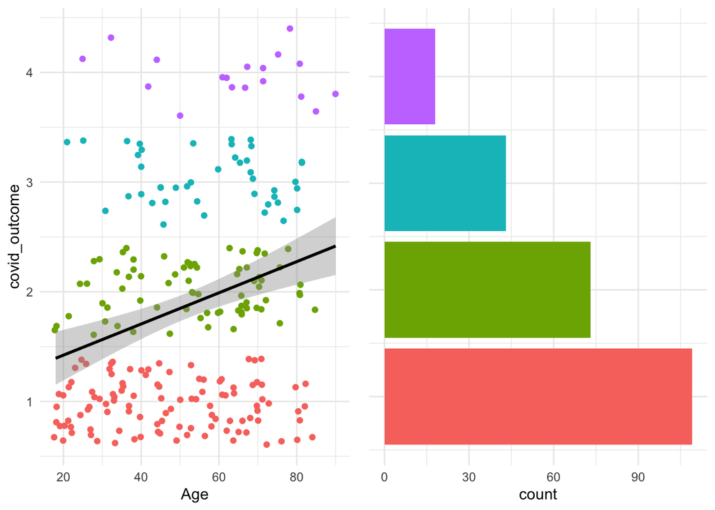

SC1 = Which of the following symptoms are you experiencing that are directly related to the current situation with COVID-19/coronavirus?

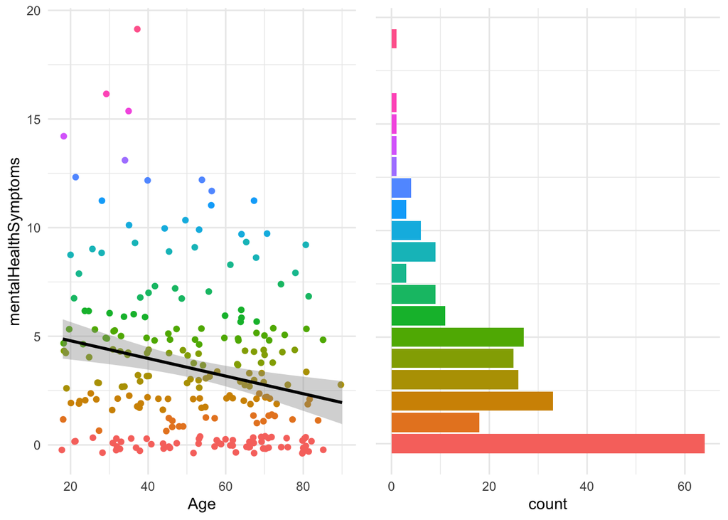

|  | colnames(data) | Q5 |
| --- | --- | --- |
| 1 | Q5 | 1 [NaN, NaN] |
| 2 | Q16_1 | 0.24 [0.12, 0.36] |
| 3 | Q16_2 | -0.08 [-0.2, 0.05] |
| 4 | Q16_3 | -0.18 [-0.3, -0.06] |
| 5 | Q16_4 | -0.22 [-0.33, -0.09] |
| 6 | Q16_5 | -0.11 [-0.24, 0.01] |
| 7 | Q16_6 | 0.15 [0.02, 0.27] |
| 14 | discountdiff | 0.06 [-0.06, 0.19] |
| 15 | valuediff | -0.05 [-0.17, 0.08] |

Q16_1 = When you leave the home, what are your main reasons for leaving? (rank in order of most to least important) - Have to do my job/work lower scores = higher rank

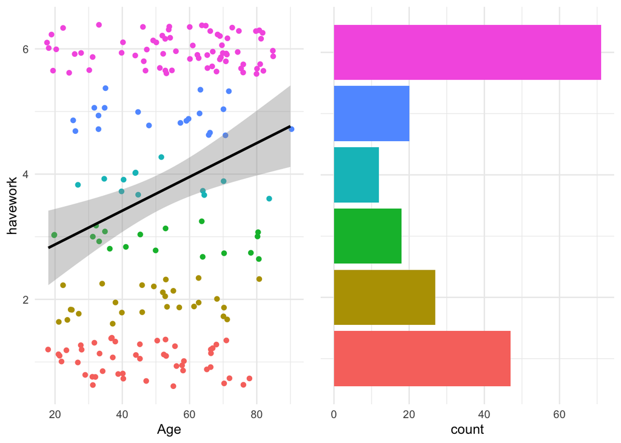

Q16_2 = When you leave the home, what are your main reasons for leaving? (rank in order of most to least important) - Pick up essential items (food, medicine, etc) lower scores = higher rank  
**Q16_2’s correlation with age is not significant in replication sample.**

Q16_5 = When you leave the home, what are your main reasons for leaving? (rank in order of most to least important) - Do something important/meaningful for the community lower scores = higher rank

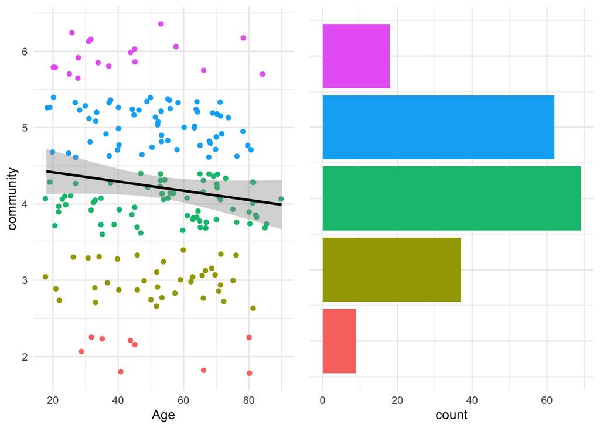

| colnames(data) | Q5 |
| --- | --- |
| Q5 | 1 [NaN, NaN] |
| Q20_1 | 0.02 [-0.11, 0.15] |
| Q20_2 | 0.09 [-0.04, 0.21] |
| Q20_3 | -0.13 [-0.25, 0] |
| Q20_4 | -0.06 [-0.18, 0.07] |
| Q20_5 | 0.06 [-0.07, 0.18] |
| Q20_6 | 0.03 [-0.1, 0.16] |

Q20_1 = When someone who doesn’t live with you has visited your home, what are the main reasons for their visit? (rank in order of most to least important) - To enable me to do my job/work (lower scores = higher rank)  
**Q20_1 is not significant in replication sample.**

Q20_2 = When someone who doesn’t live with you has visited your home, what are the main reasons for their visit? (rank in order of most to least important) - To deliver essential items (food, medicine, etc)  
**Q20_2 is not significant in replication sample**

Q20_6 = When someone who doesn’t live with you has visited your home, what are the main reasons for their visit? (rank in order of most to least important) - To provide essential care to me or a family member in my home (lower scores = higher rank) **Q20_6 is not significant in replication sample**

| colnames(data) | Q5 |
| --- | --- |
| Q5 | 1 [NaN, NaN] |
| Q22_1 | -0.31 [-0.42, -0.19] |
| Q22_2 | 0.2 [0.07, 0.32] |
| Q22_3 | 0.05 [-0.08, 0.17] |
| Q22_4 | -0.02 [-0.14, 0.11] |
| Q22_5 | 0.1 [-0.03, 0.22] |

Q22_1 = If you are staying home and social distancing, what are the main reasons? (rank in order of importance to you) - Keep myself healthy (lower scores = higher rank)

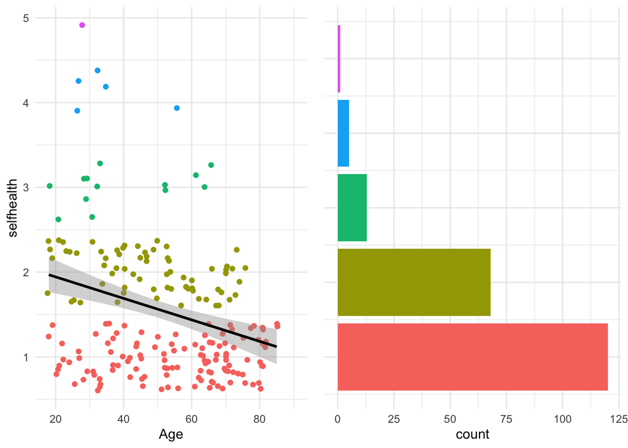

Q22_2 = If you are staying home and social distancing, what are the main reasons? (rank in order of importance to you) - Keep my family healthy (lower scores = higher rank)

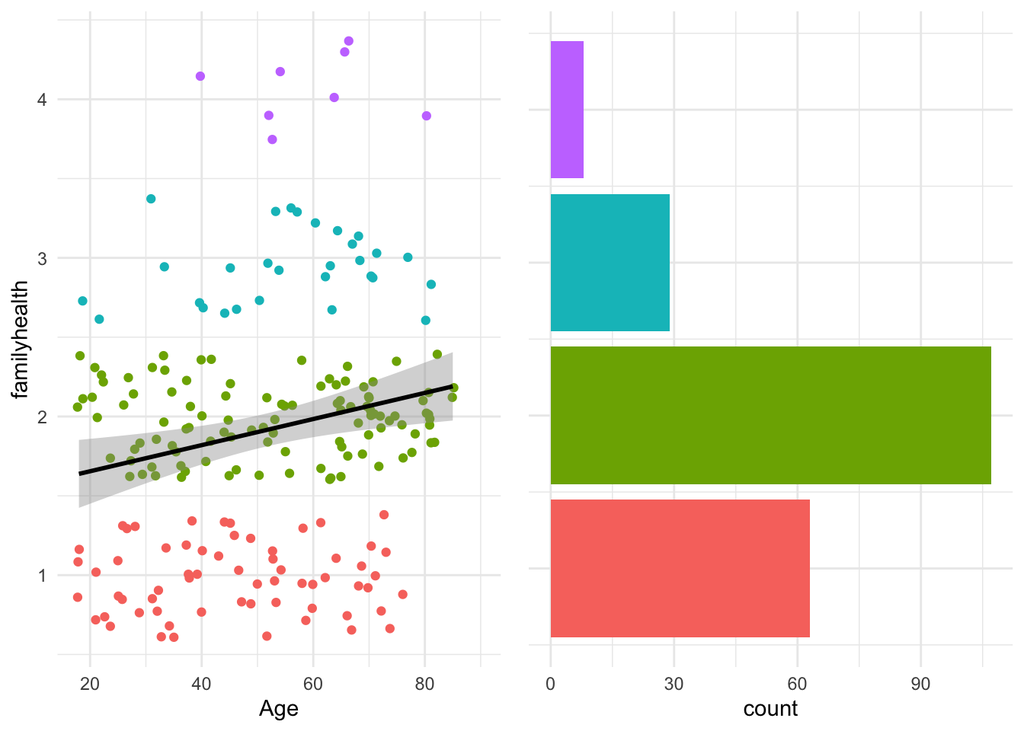